# POLS 2972Q

Quantitative Analysis in Political Science

Lecture 16 |

Predicting Binary Outcomes Using Linear Regression

## Today’s Question

In the linear model $\hat{Y} = \hat{\alpha} + \hat{\beta}X$, the slope coefficient,$\hat{\beta}$, can be interpreted as

A. the predicted Y when X=0

B. the expected change in the predicted Y when X=0

C. the predicted Y when X increases by one

D. the expected change in the predicted Y when X increases by one

## Plan for Today

- Prediction and Linear Regression
- Example with Binary Outcome Variable:
  - Using Midterm Scores to Predict Probability of Earning an A (includes A and A minus)

A. Load and explore data

B. Identify X and Y

C. What is the relationship between X and Y? (scatter plot and correlation)

D. Fit a linear model using the least squares method

E. Interpret coefficients

F. Make predictions

G. Measure how well the model fits the data

## Using Midterm Scores to Predict the Probablity of Earning an “A”

**1. Load an Explore Data**

```r
data <- read.csv("grades.csv")

head(data)
```

```
  midterm final overall gradeA
1   79.25 47.00    69.2      0
2   96.25 87.75    94.3      1
3   58.25 37.75    62.0      0
4   54.50 62.00    72.4      0
5   83.00 39.75    72.4      0
6   41.75 49.50    59.5      0
```

- What’s the unit of observation?
- For each variable: type and unit of measurement
- Substantively interpret the first observation

**2. Identify X and Y**

- The predictor (X) is the variable we want to use to predict the outcome (Y)
  - In this case, the predictor is midterm
  - Let’s visualize the distribution of midterm

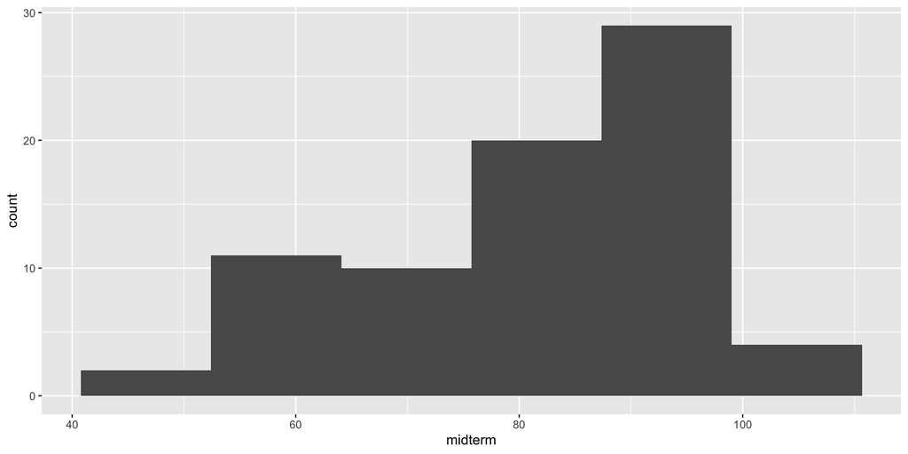

```r
ggplot(data = data) +
  geom_histogram(mapping = aes(x = midterm), bins = 6)
```

- The outcome (Y) is the variable that we want to predict
  - In this case, the outcome variable is “gradeA”
  - Let’s visualize the distribution of “gradeA”

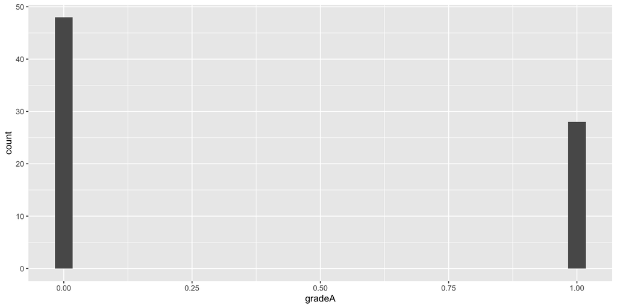

```r
ggplot(data = data) +
  geom_histogram(mapping = aes(x = gradeA))
```

- What type of variable is gradeA?
  - Binary
- How would you compute the proportion of students who received a grade A (includes A and A minus)?
  - By computing the mean of gradeA
  - Since gradeA is a binary variable, its mean should be interpreted as the proportion of the observations that have the characteristic identified by the variable
- Code to compute the mean of gradeA

```r
mean(data$gradeA)
```

```
[1] 0.3684211
```

- Interpretation?
  - Close to 37% of the students earned an A or A minus in the class
- RECALL: You need to multiply the output by 100
- Since Y is binary
  - Unit of measurement of $\bar{Y}$?
    - % (after x 100)
  - Unit of measurement of $\hat{\alpha}$?
    - % (after x 100)
  - Unit of measurement of $\hat{Y}$?
    - % (after x 100)
  - Unit of measurement of $\bigtriangleup\bar{Y}$?
    - p.p. (after x 100)
  - Unit of measurement of $\hat{\beta}$?
    - p.p. (after x 100)
  - Unit of measurement of $\bigtriangleup\hat{Y}$?
    - p.p. (after x 100)

**3. What is the relationship between X and Y?**

- Create scatter plot to visualize the relationship between midterm and gradeA

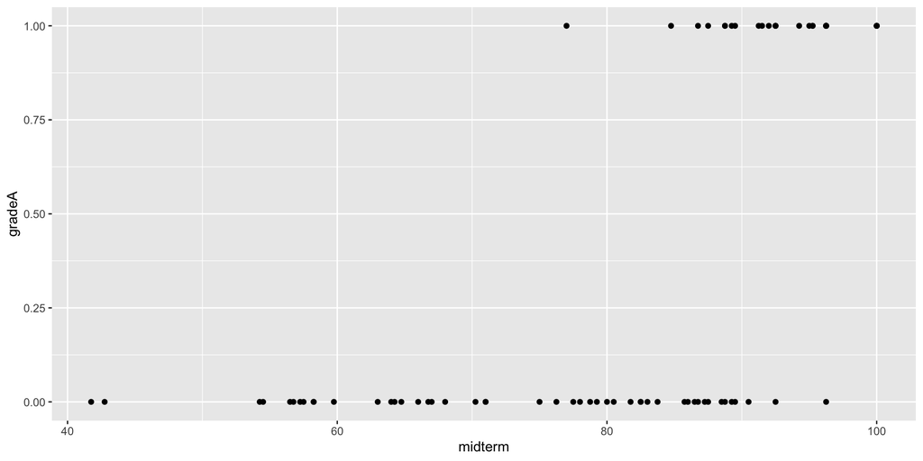

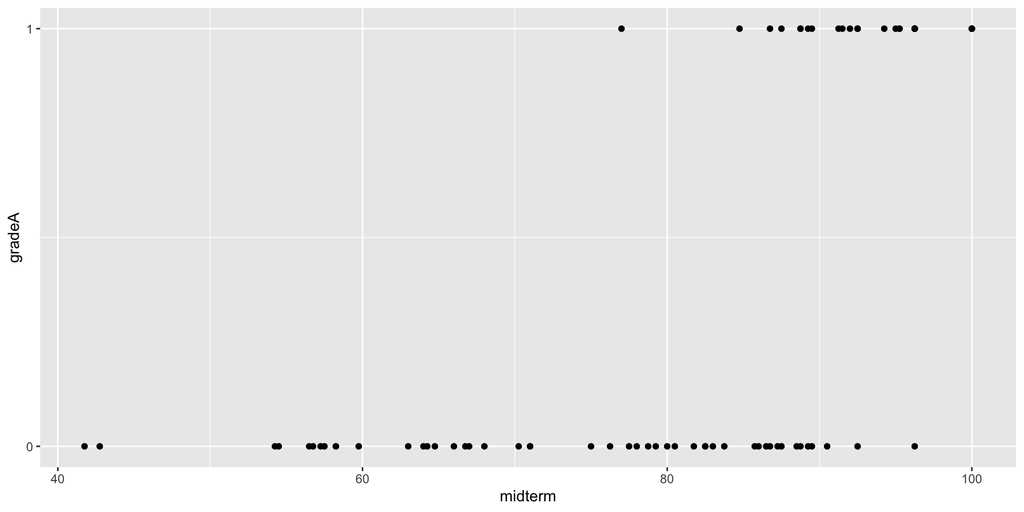

- What does each dot represent?
- Does the relationship look positive or negative?
- Does the relationship look weekly or strongly linear?
- Calculate correlation to measure direction and strength of linear association between midterm and gradeA

```r
cor(data$midterm, data$gradeA)
```

```
[1] 0.6422328
```

- We find a moderately strong positive correlation
- Are we surprised by this?
  - No because in the scatter plot above we observed that the relationship was positive and moderately strongly linear

**4. Fit a linear model using the least squares method**

- Recall, R function to fit a linear model: `lm()`
  - Require argument: a formula of type `Y ~ X`

```r
lm(gradeA ~ midterm, data = data)
```

```
Call:
lm(formula = gradeA ~ midterm, data = data)

Coefficients:
(Intercept)      midterm
   -1.34305      0.02122
```

- $\hat{\alpha}$ = -1.34 and $\hat{\beta}$ = 0.02
- The fitted line is $\hat{Y}$ = -1.34 + 0.02X
- More specifically, it is $\hat{gradeA} = -1.34 + 0.02midterm$
- R function to add fitted line to scatter plot: `abline()` or `geom_smooth()`

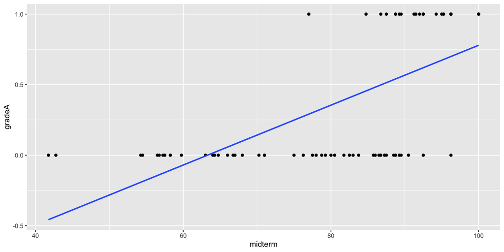

```r
fit <- lm(gradeA ~ midterm, data = data)


#tidyverse
ggplot(data = data, mapping = aes(x = midterm, y = gradeA)) +
  geom_point() +
  geom_smooth(method = "lm", se = FALSE)
```

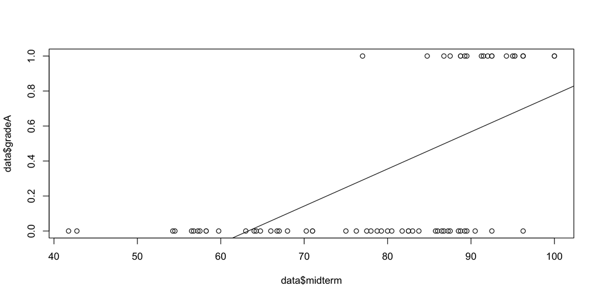

```r
#base R
plot(data$midterm, data$gradeA)
abline(fit, color = "blue")
```

**5. Interpretation of Coefficients:**

- Substantive interpretation of $\hat{\alpha}$
  - Start with mathematical definition:
    - $\hat{\alpha}$ is $\hat{Y}$ when X = 0
  - When a student scores 0 points in the midterm, we predict that their probability of earning an A in the class is -134% on average
- Sometimes it is nonsensical (due to extrapolation)
- Unit of measurement of $\hat{\alpha}$
  - Same as $\bar{Y}$
  - In this case, Y is binary and measured in points, so $\bar{Y}$ is measured in % and so is $\hat{\alpha}$
- Substantive interpretation of $\hat{\beta}$
  - $\hat{\beta}$ is the $\bigtriangleup \hat{Y}$ associated with a$\bigtriangleup \hat{X}$ = 1
  - An increase in midterm scores of 1 point is associated with a predicted increase in the probability of earning an A in the class of 2 percentage points on average
- Unit of measurement of $\hat{\beta}$
  - Same as $\bigtriangleup \bar{Y}$
  - In this case, Y is binary so $\bigtriangleup \bar{Y}$ is measure in p.p and so is $\hat{\beta}$
- **The Fitted Line Is**

$\hat{Y} = \hat{\alpha} + \hat{\beta}X$

- $\hat{\alpha}$ (alpha-hat) is the estimated intercept coefficient the $\hat{Y}$ when X = 0
- $\hat{\beta}$ (beta-hat) is the estimated intercept coefficient the $\bigtriangleup \bar{Y}$ when $\bigtriangleup \bar{X}$ = 1
- **Using the Fitted Line to Make Predictions**
- There are two types of predictions that we might be interested in
  - Predict $\hat{Y}$ based on X: $\hat{Y} = \hat{\alpha} + \hat{\beta}X$
  - Predict $\bigtriangleup \hat{Y}$ associated with $\bigtriangleup X$: $\bigtriangleup \hat{Y}$ = $\hat{\beta}\bigtriangleup X$

**6. Make Predictions**

- Example 1: Imagine you earn 80 points in the midterm, what would we predict your probability of earning an A in the class to be?

$\hat{final} = -1.34 + 0.02midterm$

$\hat{final} = -1.34 + 0.02 \times 80$ (if midterm = 80)

$\hat{final} = 0.26$

- Therefore, if you earn 80 points in the midterm, we would predict that your probability of earning an A in the class is of 26% on average
- In this case, Y is binary and measure in %
- Example 2: Imagine you earn 90 points in the midterm, what would we predict your probability of earning an A in the class to be?

$\hat{final} = -1.34 + 0.02midterm$

$\hat{final} = -1.34 + 0.02 \times 90$ (if midterm = 90)

$\hat{final} = 0.46$

- Therefore, if you earn 90 points in the midterm, we would predict that your probability of earning an A in the class is of 46% on average
- To predict $\bigtriangleup \bar{Y}$ associated with $\bigtriangleup X$: $\bigtriangleup \hat{Y}$ = $\hat{\beta}\bigtriangleup X$
- Example 3: If you increase your midterm scores by 10 points, by how much would we predict that your gradeA exam scores would change?

$\bigtriangleup\hat{final} = 0.02\bigtriangleup midterm$

$\bigtriangleup\hat{final} = 0.02 \times 10$ (if $\bigtriangleup$ midterm = 10)

$\bigtriangleup\hat{final} = 0.2$

- Therefore, an increase of midterm scores of 10 points is associated with a predicted increase in the probability of earning an A in the class f 20 percentage points

**7. Measure how well the model fits the data with** $R^2$

- How good is the model at making predictions? How well does the model fit the data?
- One way of answering is by calculating $R^2$
- $R^2$ measures the proportion of the variation in the outcome variable explained by the model
  - It ranges from 0 to 1
  - The higher the better the model fits the data
  - In the simple linear model: $R^2 = cor(X, Y)^2$
  - The higher the correlation between X and Y (in absolute terms) the better the model fits the data

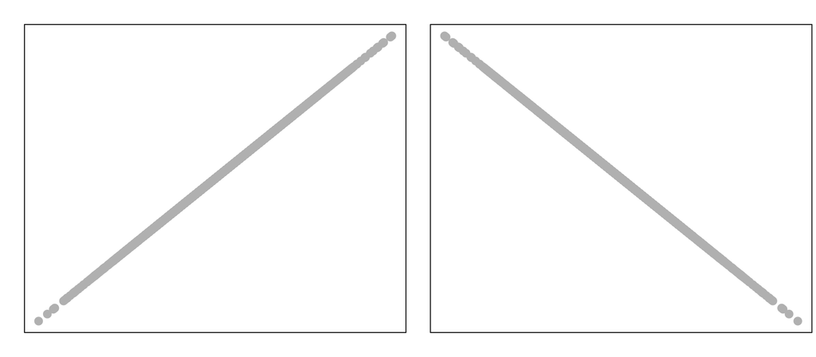

- When cor(X,Y) = 1 or cor(X,Y) = -1, the relationship between X and Y is perfectly linear
- $R^2$ = cor(X,Y)2 = 1, the model explains 100% of the variation of Y
- All prediction errors (vertical distance between the dots and the line) = 0

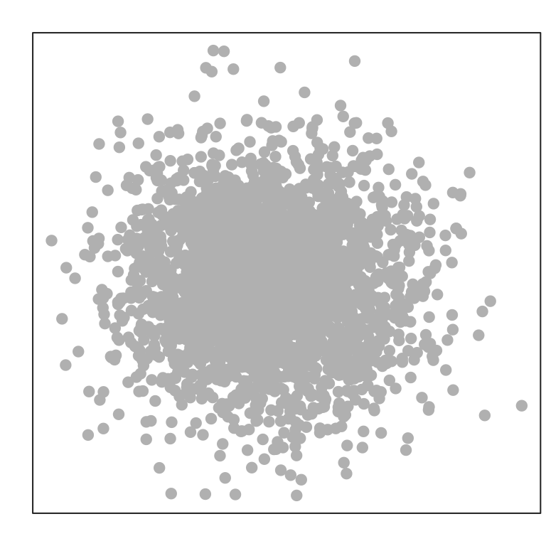

- When cor(X,Y) = 0, the relationship between X and Y is non-linear
- $R^2$ = cor(X,Y)2= 0, the model explains 0% of the variation of Y
- The prediction errors (vertical distance between the dots and the line) are very large

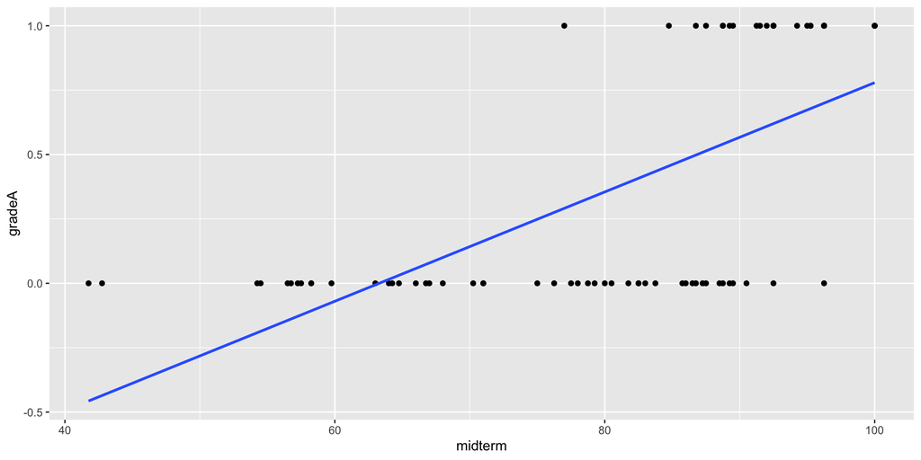

```r
#tidyverse
ggplot(data = data, mapping = aes(x = midterm, y = gradeA)) +
  geom_point() +
  geom_smooth(method = "lm", se = FALSE)
```

- Let’s compute $R^2$

```r
cor(data$midterm, data$gradeA)^2
```

```
[1] 0.4124629
```

```r
#check
model1 <- lm(gradeA ~ midterm, data = data)
summary(model1)
```

```
Call:
lm(formula = gradeA ~ midterm, data = data)

Residuals:
     Min       1Q   Median       3Q      Max
-0.69960 -0.35739  0.09093  0.32162  0.70893

Coefficients:
             Estimate Std. Error t value Pr(>|t|)
(Intercept) -1.343053   0.241313  -5.566 3.98e-07 ***
midterm      0.021222   0.002944   7.208 4.02e-10 ***
---
Signif. codes:  0 '***' 0.001 '**' 0.01 '*' 0.05 '.' 0.1 ' ' 1

Residual standard error: 0.3747 on 74 degrees of freedom
Multiple R-squared:  0.4125,    Adjusted R-squared:  0.4045
F-statistic: 51.95 on 1 and 74 DF,  p-value: 4.024e-10
```

- Interpretation?
  - It does NOT mean that the model is right 41% of the time; It means that the linear model explains 41% of the variation of the outcome variable (gradeA)
- Let’s return to the predictive model from last lecture:

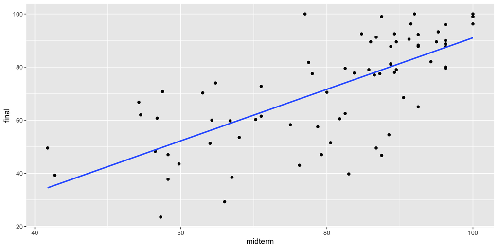

```r
ggplot(data = data, mapping = aes(x = midterm, y = final)) +
  geom_point() +
  geom_smooth(method = "lm", se = FALSE)
```

- R code to compute $R^2$

```r
cor(data$midterm, data$final)^2
```

```
[1] 0.5127023
```

```r
#check
model2 <- lm(final ~ midterm, data = data)
summary(model2)
```

```
Call:
lm(formula = final ~ midterm, data = data)

Residuals:
    Min      1Q  Median      3Q     Max
-34.789  -7.522   2.138   8.616  31.284

Coefficients:
            Estimate Std. Error t value Pr(>|t|)
(Intercept)  -6.0059     9.0133  -0.666    0.507
midterm       0.9704     0.1100   8.824 3.58e-13 ***
---
Signif. codes:  0 '***' 0.001 '**' 0.01 '*' 0.05 '.' 0.1 ' ' 1

Residual standard error: 14 on 74 degrees of freedom
Multiple R-squared:  0.5127,    Adjusted R-squared:  0.5061
F-statistic: 77.86 on 1 and 74 DF,  p-value: 3.581e-13
```

- Interpretation?
  - It does NOT mean that the model is right 51% of the time; It means that the linear model explains 51% of the variation of the outcome variable (final)
- Warning: only compare R2 between models with the same outcome variable (Y ); some variables are intrinsically harder to predict than others

## For Next Class

- Review what you learned today
- Do new set of readings:
  - We are going to examine estimating causal effects with observational data
  - DASS Chapter 5
    - Follow along the exercises with your own computer
- Bring your laptops to class